# Segmentación de clientes

```
## Mostrando variable: year_birth
```

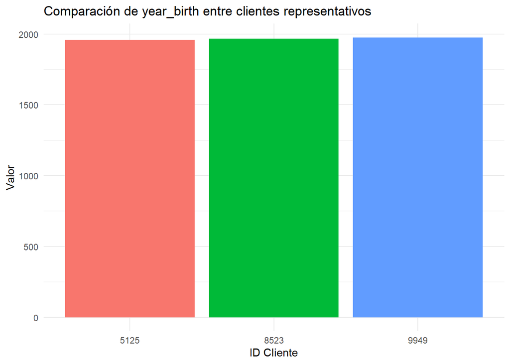

```
## Presiona [Enter] para mostrar la siguiente variable...
## Mostrando variable: income
```

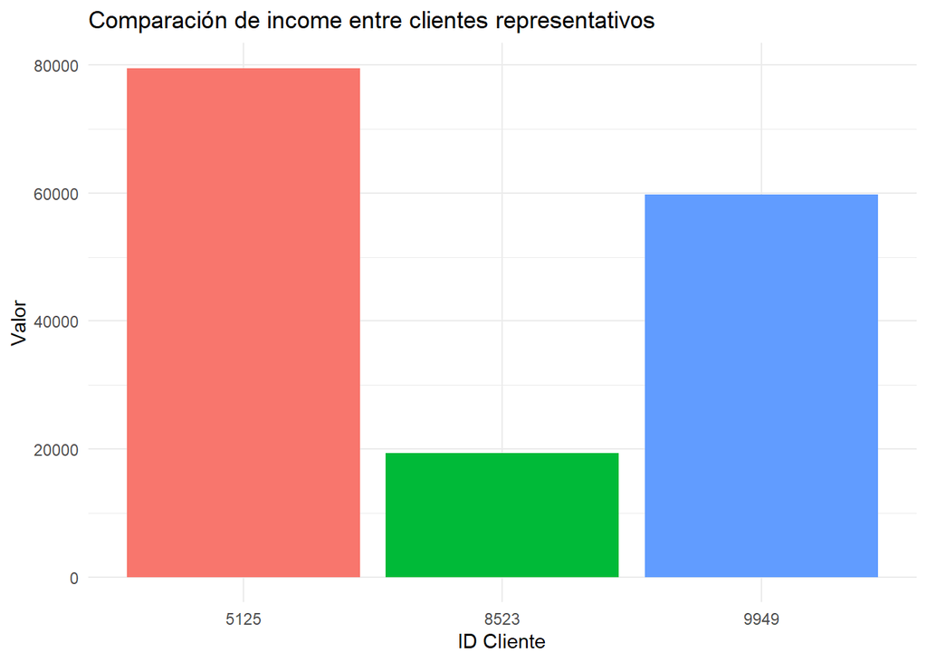

```
## Presiona [Enter] para mostrar la siguiente variable...
## Mostrando variable: kidhome
```

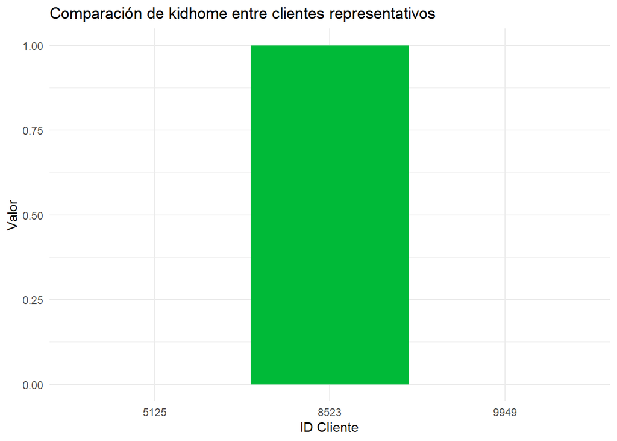

```
## Presiona [Enter] para mostrar la siguiente variable...
## Mostrando variable: teenhome
```

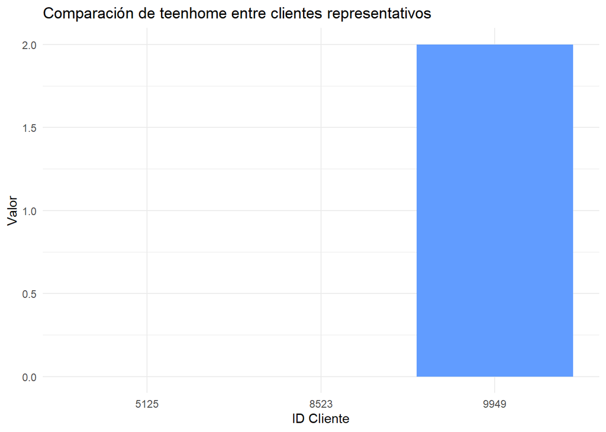

```
## Presiona [Enter] para mostrar la siguiente variable...
## Mostrando variable: recency
```

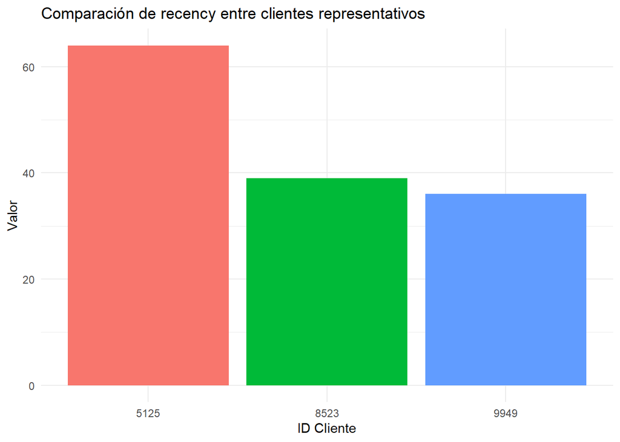

```
## Presiona [Enter] para mostrar la siguiente variable...
## Mostrando variable: mnt_wines
```

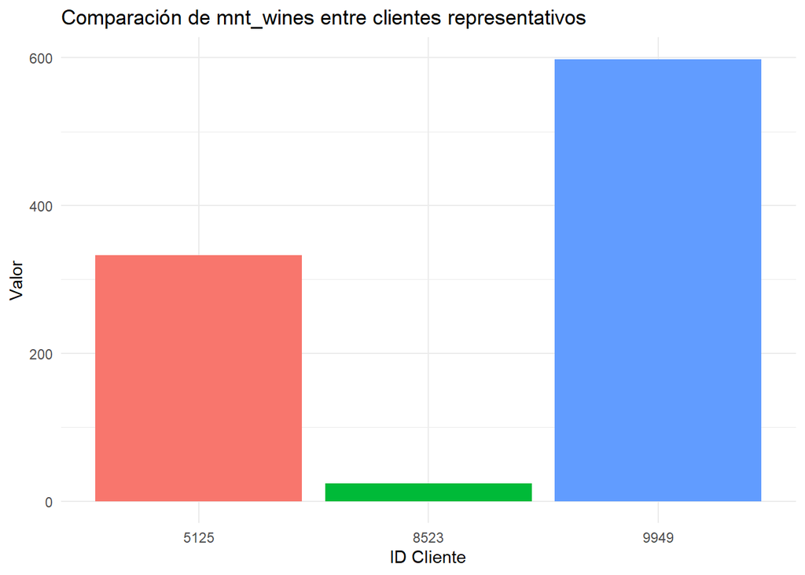

```
## Presiona [Enter] para mostrar la siguiente variable...
## Mostrando variable: mnt_fruits
```

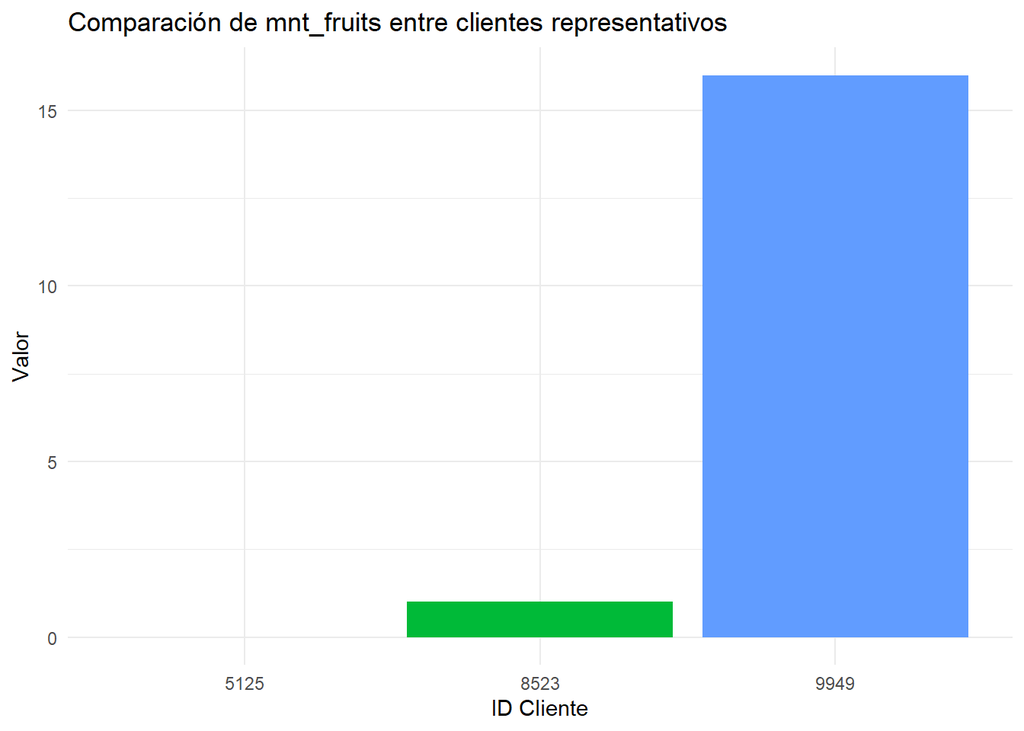

```
## Presiona [Enter] para mostrar la siguiente variable...
## Mostrando variable: mnt_meat_products
```

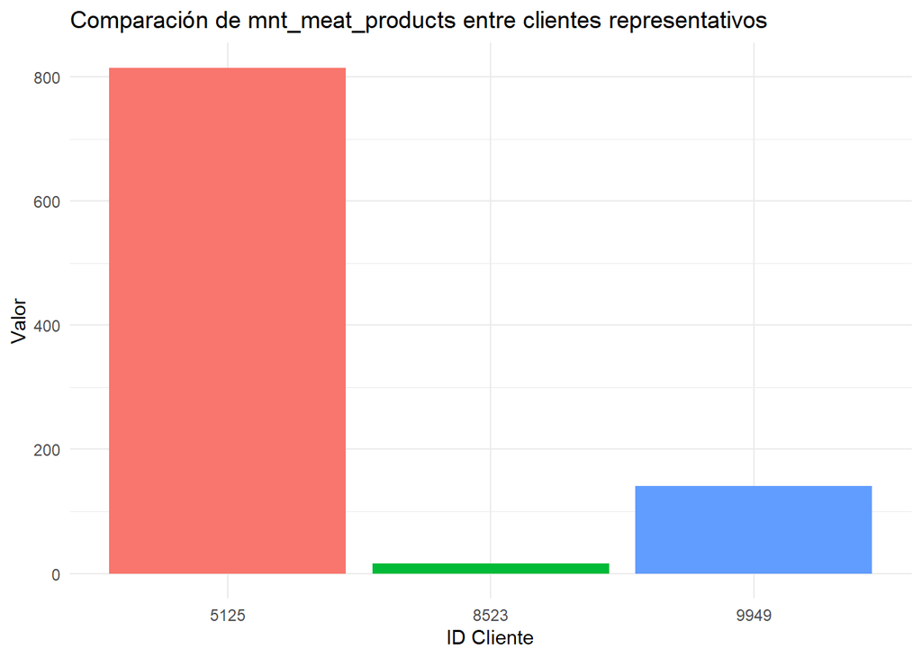

```
## Presiona [Enter] para mostrar la siguiente variable...
## Mostrando variable: mnt_fish_products
```

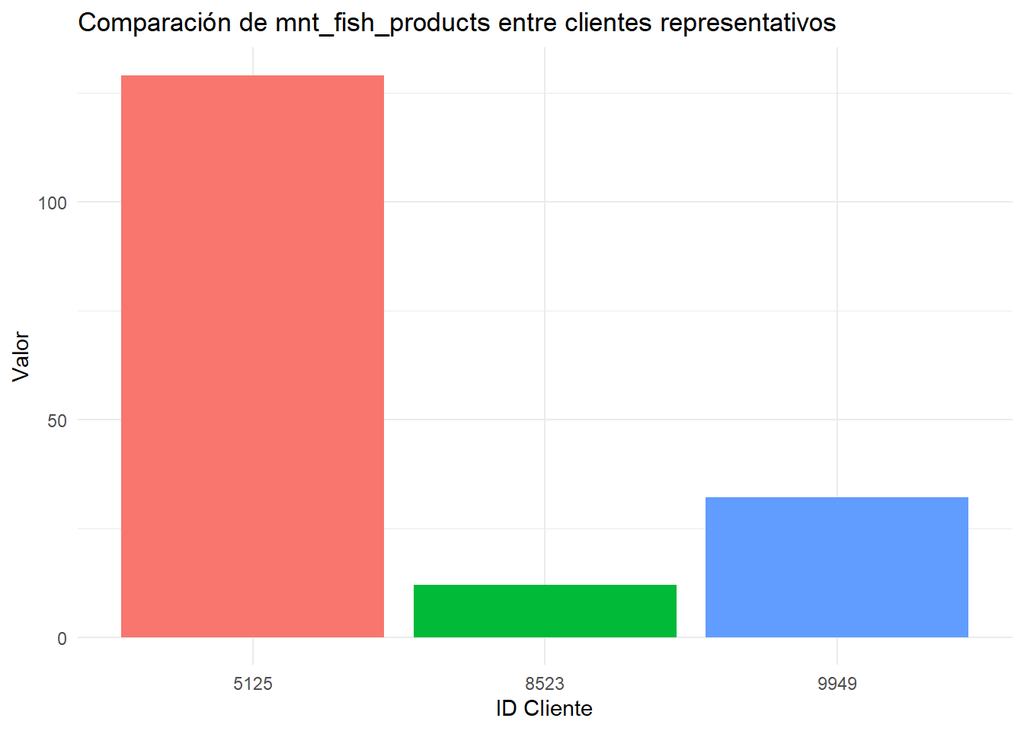

```
## Presiona [Enter] para mostrar la siguiente variable...
## Mostrando variable: mnt_sweet_products
```

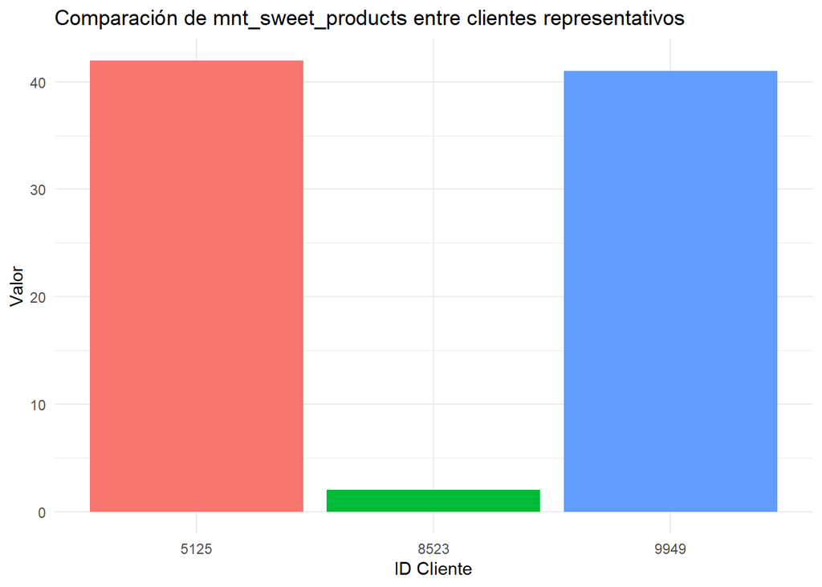

```
## Presiona [Enter] para mostrar la siguiente variable...
## Mostrando variable: mnt_gold_prods
```

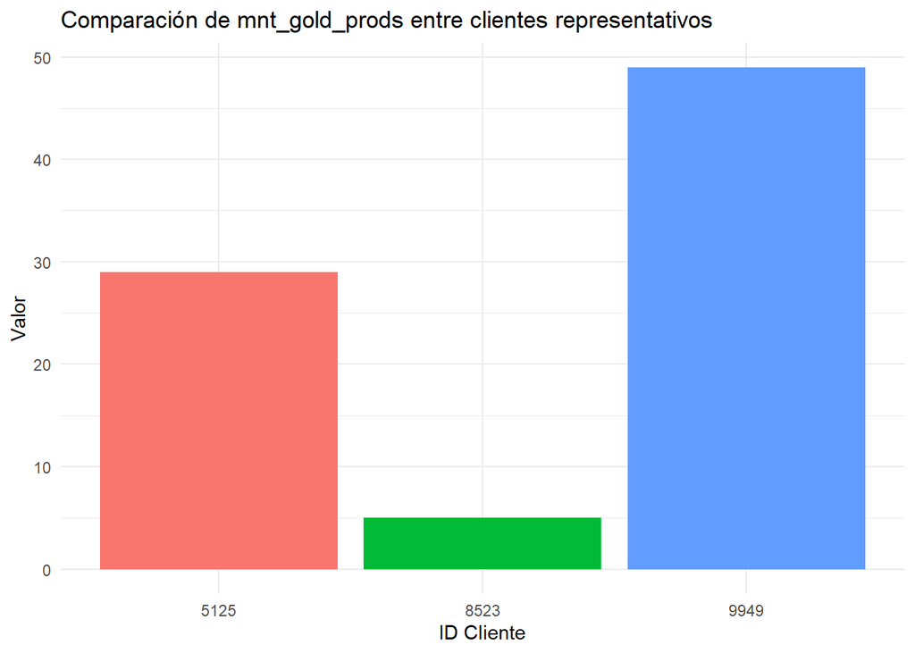

```
## Presiona [Enter] para mostrar la siguiente variable...
## Mostrando variable: num_deals_purchases
```

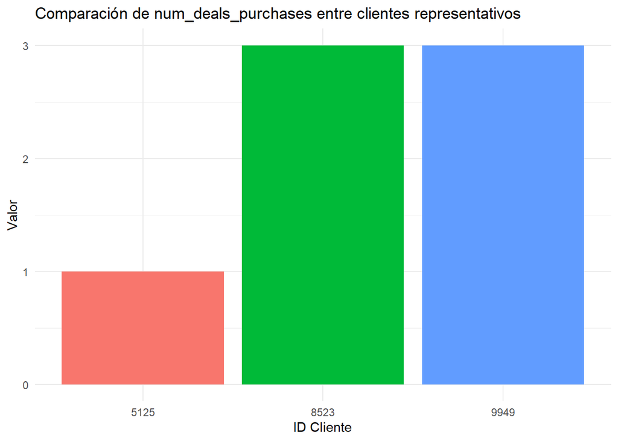

```
## Presiona [Enter] para mostrar la siguiente variable...
## Mostrando variable: num_web_purchases
```

[26 more figures not shown]

```
## Presiona [Enter] para mostrar la siguiente variable...
```

```r
library(dplyr)
library(tidyr)
library(ggplot2)

# IDs de clientes representativos
ids_representativos <- c(8523, 5125, 9949)

# Extraer datos de esos clientes (excluyendo columnas no numéricas o irrelevantes)
vars_a_comparar <- df_prepared %>%
  select(-id, -cluster, -dt_customer, -response) %>%  # ajusta según columnas que tengas
  select(where(is.numeric)) %>%  # solo variables numéricas
  colnames()

df_clientes <- df_prepared %>%
  filter(id %in% ids_representativos) %>%
  select(id, all_of(vars_a_comparar))

# Pasar a formato largo para ggplot
df_long <- df_clientes %>%
  pivot_longer(-id, names_to = "variable", values_to = "valor")

# Lista de variables únicas
variables <- unique(df_long$variable)

# Bucle para graficar cada variable individualmente
for (var in variables) {
  cat("Mostrando variable:", var, "\n")

  df_plot <- df_long %>% filter(variable == var)

  p <- ggplot(df_plot, aes(x = factor(id), y = valor, fill = factor(id))) +
    geom_col(show.legend = FALSE) +
    labs(title = paste("Comparación de", var, "entre clientes representativos"),
         x = "ID Cliente",
         y = "Valor") +
    theme_minimal()

  print(p)

  readline(prompt = "Presiona [Enter] para mostrar la siguiente variable...")
}
```

### Conclusiones

- El cluster 1 agrupa clientes con ingresos más bajos, menor gasto y menor respuesta a promociones, con más niños en casa y menor actividad de compra.
- El cluster 2 representa a los clientes con mayor poder adquisitivo y mayor gasto, que responden mejor a promociones y compran mucho en tienda y catálogo.
- El cluster 3 es un grupo activo en canales digitales (web), con ingresos medios y buen nivel de gasto.